# Phos-Chek & Burning on Plant Diversity

Luka Negoita

2/22/2019

### Introduction

**This is an analysis on testing the effect of burning or phos-chek application (without burning) on:** **1. diversity of species** **2. relative abundance of non-native species**

### Load Packages

The first step is to load all the packages that give us the tools we will need in this script:

```r
# install.packages("vegan") # use this first if the package is not already installed
library("vegan") # package with tools for VEGetation ANalysis
library("tidyverse") # package with essential tools for data cleaning and manipulation
library("lme4") # package for mixed effect models
library("emmeans")
library("betareg")
library("lmtest")
# devtools::install_github("glmmTMB/glmmTMB",sub="glmmTMB")
library("glmmTMB")
```

### Upload the data

Now, upload the data from the raw CSV file and separate out the species covers from the rock, etc covers. I don’t know what “Thatch” means, but I’m assuming it’s not a species cover

```r
# Upload the data:
all_dat <- read_csv("data/2018&2019springcoverdataR.csv")
nativity <- read_csv("data/N vs NN_NR_LN.csv")

# Attach nativity to main data:
all_dat <- left_join(all_dat, nativity, by="Species_Name")

# Look at the list of species names to see which ones are not species:
unique(all_dat$Species_Name)

# Extract just the non-species covers:
non_spp_cov <- filter(all_dat,
                      grepl("Rock",Species_Name) | # the '|' operator means OR
                      grepl("Thatch",Species_Name) |
                      grepl("ground",Species_Name))
# 'grepl()' searches for a text pattern within a vector, in this case "Species_Name"

# And here extract just the species covers:
spp_cov <- filter(all_dat,
                      !grepl("Rock",Species_Name) & # the '&' operator means AND
                      !grepl("Thatch",Species_Name) &
                      !grepl("ground",Species_Name))
# the '!' operator means NOT, meaning that it reverses TRUE and FALSE, thus where is "Rock" NOT found...
```

### Adjust the plot covers

Now, we need to adjust the total area of each plot to the proportion of the plot within which a plant can actually grow. Saying that a certain species covers only 60% of a plot is misleading if 40% of the plot is bare rock. That species should actually be treated as covering 100% of the “livable” area of the plot. Note that in some cases species may have over 100% cover (since they can spread over the rock area), but this is fine and will not affect the calculation of diversity indices.

To adjust the plot covers, first summarize the average rock cover for each plot (since it was measured twice for the same plot sometimes), and convert it to soil cover (the inverse of rock cover):

```r
soil_cover <- group_by(non_spp_cov, Plot_Name) %>% # within each Plot_Name...
  summarize(Q1.soil = 100-mean(Q1), # summarize each subplot rock cover and convert to soil cover
            Q2.soil = 100-mean(Q2),
            Q3.soil = 100-mean(Q3),
            Q4.soil = 100-mean(Q4))
```

Next, join those soil covers to the species covers:

```r
spp_cov_all <- left_join(spp_cov, soil_cover, by="Plot_Name")
```

Finally, adjust the species covers according to these soil covers by dividing each species cover by the total potential grow-able area (the soil covers we had just calculated):

```r
# Adjust the species covers according to the soil covers.
# also multiply by 100 to keep in percentage units and round to the nearest percentage unit
spp_cov_adj <- mutate(spp_cov_all,
                      Q1 = round((Q1/Q1.soil)*100),
                      Q2 = round((Q2/Q2.soil)*100),
                      Q3 = round((Q3/Q3.soil)*100),
                      Q4 = round((Q4/Q4.soil)*100),
                      Mean_Cover = (Q1+Q2+Q3+Q4)/4)
# also recalculate total cover, which I've renamed to mean cover since that's actually what it means
```

### Create species X plot matrix

Now to calculate diversity indices we need to create a complete matrix of all species in each site. The matrix is complete because species that did not occur in a particular plot are simply assigned a value of zero. For this analysis, I calculate everything at the quad or subplot level since we can run the analyses on that level for extra power (larger sample size), and we make up for the pseudoreplication of four data points (quads) within each plot by include “plot” as a random effect–but more on that later…

```r
# Clean up the data frame by selecting only the useful columns
spp_cov_fin <- select(spp_cov_adj, -contains("soil"), -Total_Cover, -Mean_Cover) %>%
  gather(quad, cover, Q1:Q4) %>%
  mutate(year_subplot = paste(Year,Plot_Name,quad,sep="_")) #

# Now, save just the plot-level data separately (used for analyses later):
plot_data <- select(spp_cov_fin, -Species_Name, -Date, -Season, -cover, -quad, -native) %>%
  unique()

# Extract just the cover data for each year_subplot and create a matrix.
# Note that in some cases you entered a cover more than once for the
# same species in the same plot on the same date. Because of that, I
# just average the values. If you think those are data entry mistakes,
# you can just fix them in the original data.
covers <- select(spp_cov_fin, -Date, -Season, -Substrate, -Treatment,
                 -Aspect, -Plot, -Year, -Plot_Name, -quad) %>%
  group_by(Species_Name, year_subplot) %>%
  summarize(cover = mean(cover)) %>%
  spread(key=Species_Name, value=cover, fill=0)

# Convert covers to a matrix and add year_subplot as row_names,
# then remove the year_subplot name column:
spp_plot <- data.matrix(covers)
row.names(spp_plot) <- covers$year_subplot
spp_plot <- spp_plot[,-1] # only run this line once or you'll delete each following first column
```

### Calculate Diversity Indices

Now we can get on with actually calculating the diversity indices. First, make a custom function for the Shannon an Simpson indices to make it easier to use them with the *apply* function:

```r
# define our own diversity functions:
shan <- function(x) diversity(x, index="shannon")
simp <- function(x) diversity(x, index="simpson")
```

Now, calculate diversity indices for each row (year_plot_subplot combo) in the matrix:

```r
# Use the apply function to apply each diversity function to all the rows (MARGIN = 1) in the matrix
shannon_div <- apply(spp_plot, MARGIN=1, FUN=shan)
simpson_div <- apply(spp_plot, MARGIN=1, FUN=simp)

# Then create a data frame (actually called a tibble when using the Tidy package) with these results:
plot_div <- tibble(year_subplot = names(shannon_div), shannon = shannon_div, simpson = simpson_div)

plot_div
```

```
## # A tibble: 144 x 3
##    year_subplot   shannon simpson
##    <chr>            <dbl>   <dbl>
##  1 2018_NS-BS1_Q1   1.89    0.832
##  2 2018_NS-BS1_Q2   1.47    0.694
##  3 2018_NS-BS1_Q3   1.82    0.803
##  4 2018_NS-BS1_Q4   1.66    0.770
##  5 2018_NS-BS2_Q1   1.28    0.584
##  6 2018_NS-BS2_Q2   1.38    0.711
##  7 2018_NS-BS2_Q3   0.937   0.462
##  8 2018_NS-BS2_Q4   1.90    0.789
##  9 2018_NS-BS3_Q1   1.70    0.759
## 10 2018_NS-BS3_Q2   1.55    0.724
## # … with 134 more rows
```

Finally, append these results back to the plot data, and fix up the dataframe for analysis

```r
# Finally, append these results back to the plot data, and fix up the dataframe for analysis
final_div_data <- left_join(plot_data, plot_div, by="year_subplot") %>%
  select(-Plot, -Substrate, -Aspect) %>% # don't need the year_plot column (or "plot") anymore
  mutate(Plot_Name = as.factor(Plot_Name), # these columns need to be converted to factors
         Treatment = as.factor(Treatment),
         quad = str_sub(year_subplot, start= -2),
         Year = Year-min(Year)) %>% # scale year it so that it's just year 0 and year 1
  select(-year_subplot) %>%
  unique()
```

### Analyze effects on diversity

#### 1) First analyze the effects of treatment (burning or phoschek or noburning) on diversity index

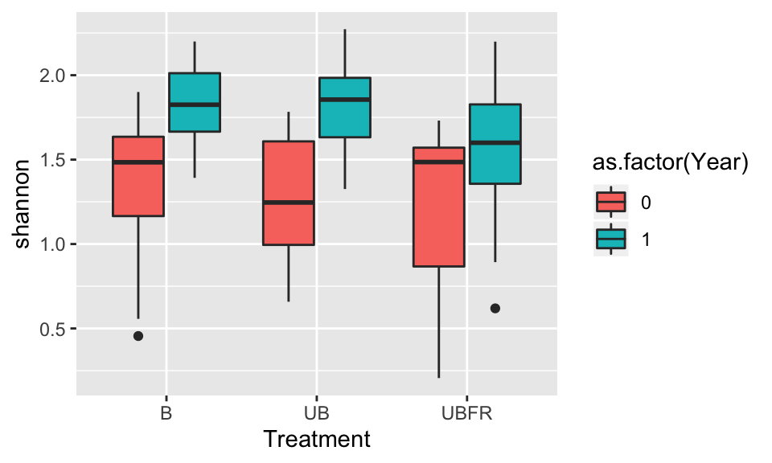

```r
# Basic plot of Shannon index for each treatment and year:
final_div_data %>%
  ggplot(aes(x=Treatment, y=shannon, fill=as.factor(Year))) +
    geom_boxplot()
```

The question of interest here is the interaction effect between year and treatment. You can also think of this as testing for differences between the slope of the line within each treatment that goes from 2018 to 2019.

To test this, let’s first test whether there is an overall significant interaction effect here. Then we can conduct pairwise comparisons between each treatment-year interaction to see if any are significantly higher or lower than the others.

To test for an overall effect, we can’t immediately get P-values from a mixed effect model like we can with a basic model, so we have to use a likelihood ratio test that compared two models–that’s what gets us a P-value.

```r
# General Mixed-effect regression model with interaction effect:
mod_interaction <- lmer(shannon~Treatment+Year+Treatment*Year+(1|Plot_Name), data=final_div_data, REML=F)
# REML = F is hard to explain, but just know this argument is important for us to be able to compare this to the NULL model in the next step

# General Mixed-effect regression model WITHOUT interaction effect:
mod_null <- lmer(shannon~Treatment+Year+(1|Plot_Name), data=final_div_data, REML=F)

# Now same for simpson diversity:
mod_interaction_simp <- lmer(simpson~Treatment+Year+Treatment*Year+(1|Plot_Name), data=final_div_data, REML=F)
mod_null_simp <- lmer(simpson~Treatment+Year+(1|Plot_Name), data=final_div_data, REML=F)
```

And now perform the likelihood-ratio test of comparing these models. A significant result (P-value less than 0.05) indicates that the two models are significantly different in their ability to fit your data, indicating that the parameter missing from the null model is a significantly important component of the full model. In other words, the interaction effect is significant, meaning that treatment has a significant effect on diversity.

```r
# Perform a likelihood ratio test using Chi-squared test to see if the models are significantly different
lrtest(mod_interaction,mod_null)
```

```
## Likelihood ratio test
##
## Model 1: shannon ~ Treatment + Year + Treatment * Year + (1 | Plot_Name)
## Model 2: shannon ~ Treatment + Year + (1 | Plot_Name)
##   #Df  LogLik Df  Chisq Pr(>Chisq)
## 1   8 -41.549
## 2   6 -43.897 -2 4.6958    0.09557 .
## ---
## Signif. codes:  0 '***' 0.001 '**' 0.01 '*' 0.05 '.' 0.1 ' ' 1
```

```r
lrtest(mod_interaction_simp,mod_null_simp)
```

```
## Likelihood ratio test
##
## Model 1: simpson ~ Treatment + Year + Treatment * Year + (1 | Plot_Name)
## Model 2: simpson ~ Treatment + Year + (1 | Plot_Name)
##   #Df LogLik Df  Chisq Pr(>Chisq)
## 1   8  85.62
## 2   6  85.39 -2 0.4614      0.794
```

From this we see that neither the shannon diversity index, nor the simpson index, is significantly influenced by the interaction effect. **If you haven’t already, you should read up on and understand the difference between the Shannon and Simpson diversity indices in terms of what they mean biologically. What is the *biological significance* if only one of these two indices was significantly influenced by treatment?**

**Ok, so no general effect, bit now let’s do a pairwise comparison of this interaction effect using the emmeans package in R to compare every contrast.** This allows us to compare the interaction effects between each treatment while accounting for all the other variables in the model:

```r
# This conducts a pairwise statistical comparison of interaction effects between each treatment:
emtrends(mod_interaction, pairwise ~ Treatment, var = "Year")
```

```
## $emtrends
##  Treatment Year.trend     SE  df asymp.LCL asymp.UCL
##  B              0.485 0.0848 Inf     0.318     0.651
##  UB             0.546 0.0848 Inf     0.380     0.712
##  UBFR           0.294 0.0848 Inf     0.128     0.460
##
## Results are averaged over the levels of: Year
## Degrees-of-freedom method: asymptotic
## Confidence level used: 0.95
##
## $contrasts
##  contrast  estimate   SE  df z.ratio p.value
##  B - UB     -0.0611 0.12 Inf -0.510  0.8666
##  B - UBFR    0.1904 0.12 Inf  1.587  0.2511
##  UB - UBFR   0.2515 0.12 Inf  2.097  0.0904
##
## Results are averaged over the levels of: Year
## Degrees-of-freedom method: asymptotic
## P value adjustment: tukey method for comparing a family of 3 estimates
```

**So you can see that there pairwise interaction effects are also not significant. This is not very surprising due to the low sample size–effectively only a sample size of 6 plots in each treatment. Though your results are *real*, I think it is important to clarify the caveat that these results are based on this low sample size.**

#### 2) Now analyze the effects of treatment (burning or phoschek or noburning) on *non-native abundance*:

First calculate the relative abundance of non-native species compared to native species in each plot. One way to do this is simply to calculate the sum of non-native species abundances divided by the sum of all abundances:

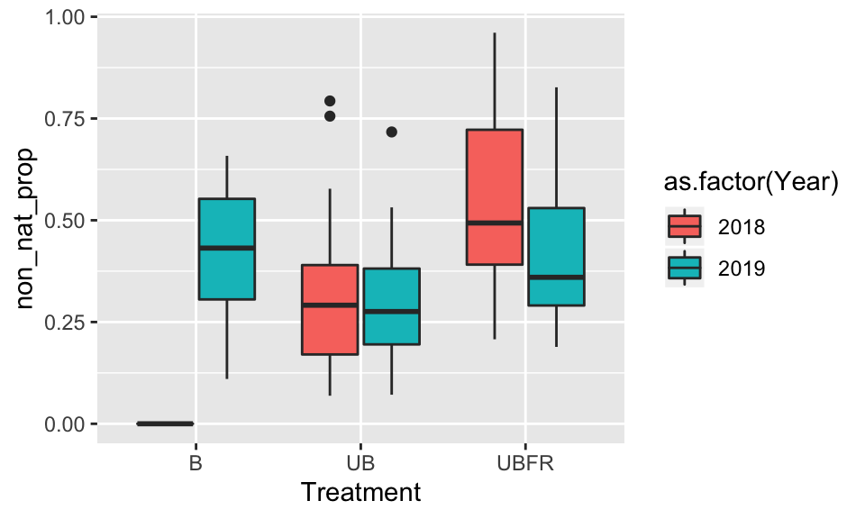

```r
spp_cov_summary <- group_by(spp_cov_fin, Plot_Name, quad, Year, Treatment, native) %>%
  summarize(tot_cover = sum(cover)) %>%
  ungroup() %>%
  group_by(Plot_Name, quad, Treatment, Year) %>%
  mutate(all_covers = sum(tot_cover),
         non_nat_cov = sum(tot_cover[which(native==0)]),
         non_nat_prop = non_nat_cov/all_covers) %>%
  select(-native, -tot_cover) %>%
  ungroup() %>%
  unique()

spp_cov_summary %>%
  ggplot(aes(x=Treatment, y=non_nat_prop, fill=as.factor(Year))) +
    geom_boxplot()
```

A quick plot of the data is striking… The Y axis is the proportion of non-native species abundance in each plot. Our goal (again) is to test for the interaction of treatment and time (is there a difference in slopes between each treatment). It appears to be so.. Burned plots went from zero non-native to almost 50% non-native, Unburned stayed almost the same, and phoschek plots decreased in non-native abundance.

Now do the same tests as before, but this time using a beta-distribution (0-1) for the cover data:

```r
# modify the cover data to ensure it is between 0 and 1:
spp_cov_summary$non_nat_prop <- ifelse(spp_cov_summary$non_nat_prop>=1, 0.99, spp_cov_summary$non_nat_prop)
spp_cov_summary$non_nat_prop <- ifelse(spp_cov_summary$non_nat_prop==0, 0.01, spp_cov_summary$non_nat_prop)
spp_cov_summary$Year <- spp_cov_summary$Year - 2018
#spp_cov_summary$Year <- as.factor(spp_cov_summary$Year)

# Mixed model beta regression:
# Good explanation here:
# https://stats.stackexchange.com/questions/233366/how-to-fit-a-mixed-model-with-response-variable-between-0-and-1
mod_interaction_beta <- glmmTMB(non_nat_prop ~ Treatment+Year+Treatment*Year+(1|Plot_Name), spp_cov_summary, family=list(family="beta",link="logit"))
mod_null_beta <- glmmTMB(non_nat_prop ~ Treatment+Year+(1|Plot_Name), spp_cov_summary, family=list(family="beta",link="logit"))
#summary(mod_interaction_beta)

# Likelihood ratio test:
lrtest(mod_interaction_beta, mod_null_beta)
```

```
## Likelihood ratio test
##
## Model 1: non_nat_prop ~ Treatment + Year + Treatment * Year + (1 | Plot_Name)
## Model 2: non_nat_prop ~ Treatment + Year + (1 | Plot_Name)
##   #Df  LogLik Df  Chisq Pr(>Chisq)
## 1   8 124.876
## 2   6  66.584 -2 116.58  < 2.2e-16 ***
## ---
## Signif. codes:  0 '***' 0.001 '**' 0.01 '*' 0.05 '.' 0.1 ' ' 1
```

So, as expected from the strong trends in the figure, there is a significant interaction effect of treatment and year on non-native abundance.

Performing the pairwise comparisons we see that they are all significant:

```r
emtrends(mod_interaction_beta, pairwise ~ Treatment, var = "Year")
```

```
## $emtrends
##  Treatment Year.trend    SE  df lower.CL upper.CL
##  B              2.966 0.239 136    2.492    3.439
##  UB            -0.080 0.169 136   -0.415    0.255
##  UBFR          -0.643 0.162 136   -0.964   -0.322
##
## Results are averaged over the levels of: Year
## Confidence level used: 0.95
##
## $contrasts
##  contrast  estimate    SE  df t.ratio p.value
##  B - UB       3.046 0.293 136 10.385  <.0001
##  B - UBFR     3.608 0.291 136 12.379  <.0001
##  UB - UBFR    0.563 0.235 136  2.398  0.0466
##
## Results are averaged over the levels of: Year
## P value adjustment: tukey method for comparing a family of 3 estimates
```

But something important to note is that the fire or phoschek application may have instantly shifted the abundance of non-native species (for example, how in the burned treatment non-native species have a cover of zero). So, just comparing the statistical difference between each treatment in each year, we can see that non-native abundance is not significantly different after one year, but it is right after treatment (in year 0, or 2018):

```r
# https://cran.r-project.org/web/packages/emmeans/vignettes/interactions.html
contrasts <- emmeans(mod_interaction_beta, ~ Treatment*Year)
pairs(contrasts, simple = "Treatment")
```

```
## Year = 0:
##  contrast  estimate    SE  df t.ratio p.value
##  B - UB     -2.5552 0.363 136 -7.039  <.0001
##  B - UBFR   -3.6340 0.364 136 -9.985  <.0001
##  UB - UBFR  -1.0788 0.318 136 -3.391  0.0026
##
## Year = 1:
##  contrast  estimate    SE  df t.ratio p.value
##  B - UB      0.4903 0.318 136  1.541  0.2749
##  B - UBFR   -0.0257 0.316 136 -0.081  0.9964
##  UB - UBFR  -0.5159 0.319 136 -1.617  0.2421
##
## Results are given on the log odds ratio (not the response) scale.
## P value adjustment: tukey method for comparing a family of 3 estimates
```

### Conclusions

#### 1) There is no significant effect of burning or phos-chek application on the diversity of species.

#### 2) Non-native species significantly *increase* in abundance one year after burning.

#### 3) Non-native species significantly *decrease* in abundance one year after application of phos-chek.

#### 4) Though non-native species abundance is significantly different between treatments immediately after the fire, that difference becomes insignificant after one year.